# Forest_Fire

Alex

2023-09-09

## 1. Introduction of the data

Here are descriptions of the variables in the data set and the range of values for each taken from the paper:

- X: X-axis spatial coordinate within the Montesinho park map: 1 to 9
- Y: Y-axis spatial coordinate within the Montesinho park map: 2 to 9
- month: Month of the year: ‘jan’ to ‘dec’
- day: Day of the week: ‘mon’ to ‘sun’
- FFMC: Fine Fuel Moisture Code index from the FWI system: 18.7 to 96.20
- DMC: Duff Moisture Code index from the FWI system: 1.1 to 291.3
- DC: Drought Code index from the FWI system: 7.9 to 860.6
- ISI: Initial Spread Index from the FWI system: 0.0 to 56.10
- temp: Temperature in Celsius degrees: 2.2 to 33.30
- RH: Relative humidity in percentage: 15.0 to 100
- wind: Wind speed in km/h: 0.40 to 9.40
- rain: Outside rain in mm/m2 : 0.0 to 6.4
- area: The burned area of the forest (in ha): 0.00 to 1090.84

The data can be categorized into:

1. Spatial data: (X,Y)
2. Temporal: month and day
3. FWI: FFC, DMC, DC, and ISI
4. M(measured data): temp, RH, wind, rain

Forest fires can create ecological problems and endanger human lives and property. Understanding when they occur and what causes them is important for managing them.The goal is to predict the area based on other variables.

P.S. The data we’ll be working with in this guided project is associated with a scientific research paper on predicting the occurrence of forest fires in Portugal using modeling techniques.

## 2. Data Cleaning

### 2.1 Read data and check the dimension

```r
library(readr)
fires <- read_csv('forestfires.csv', col_types = cols())

# Check the dimensions of the data
dimension <- dim(fires)
dimension
```

```
## [1] 517  13
```

The csv file has 517 rows and 13 columns.

### 2.2 Check the data type of each column

```r
# Check the data type
library(dplyr)
glimpse(fires)
```

```
## Rows: 517
## Columns: 13
## $ X     <dbl> 7, 7, 7, 8, 8, 8, 8, 8, 8, 7, 7, 7, 6, 6, 6, 6, 5, 8, 6, 6, 6, 5…
## $ Y     <dbl> 5, 4, 4, 6, 6, 6, 6, 6, 6, 5, 5, 5, 5, 5, 5, 5, 5, 5, 4, 4, 4, 4…
## $ month <chr> "mar", "oct", "oct", "mar", "mar", "aug", "aug", "aug", "sep", "…
## $ day   <chr> "fri", "tue", "sat", "fri", "sun", "sun", "mon", "mon", "tue", "…
## $ FFMC  <dbl> 86.2, 90.6, 90.6, 91.7, 89.3, 92.3, 92.3, 91.5, 91.0, 92.5, 92.5…
## $ DMC   <dbl> 26.2, 35.4, 43.7, 33.3, 51.3, 85.3, 88.9, 145.4, 129.5, 88.0, 88…
## $ DC    <dbl> 94.3, 669.1, 686.9, 77.5, 102.2, 488.0, 495.6, 608.2, 692.6, 698…
## $ ISI   <dbl> 5.1, 6.7, 6.7, 9.0, 9.6, 14.7, 8.5, 10.7, 7.0, 7.1, 7.1, 22.6, 0…
## $ temp  <dbl> 8.2, 18.0, 14.6, 8.3, 11.4, 22.2, 24.1, 8.0, 13.1, 22.8, 17.8, 1…
## $ RH    <dbl> 51, 33, 33, 97, 99, 29, 27, 86, 63, 40, 51, 38, 72, 42, 21, 44, …
## $ wind  <dbl> 6.7, 0.9, 1.3, 4.0, 1.8, 5.4, 3.1, 2.2, 5.4, 4.0, 7.2, 4.0, 6.7,…
## $ rain  <dbl> 0.0, 0.0, 0.0, 0.2, 0.0, 0.0, 0.0, 0.0, 0.0, 0.0, 0.0, 0.0, 0.0,…
## $ area  <dbl> 0, 0, 0, 0, 0, 0, 0, 0, 0, 0, 0, 0, 0, 0, 0, 0, 0, 0, 0, 0, 0, 0…
```

Only two columns: month and data are string data, other eleven columns are all numeric data. For categorical data, we can check the unique values and count. For the numeric data, histogram or scatter plot is a good way to see the data distribution or trends. In addition, wheter there are missing values also needs to be examined.

### 2.3 Check if there are missing value in each column

```r
# missing values
colSums(is.na(fires))
```

```
##     X     Y month   day  FFMC   DMC    DC   ISI  temp    RH  wind  rain  area
##     0     0     0     0     0     0     0     0     0     0     0     0     0
```

No missing values for each column. Therefore, we will use all the data for the modeling.

### 2.4 Check and process different type of data

#### 2.4.1 Check the datatype of each column

```r
# Check the unique values of the columns with categorical values

fires %>% pull(month) %>% unique
```

```
##  [1] "mar" "oct" "aug" "sep" "apr" "jun" "jul" "feb" "jan" "dec" "may" "nov"
```

```r
fires %>% pull(day) %>% unique
```

```
## [1] "fri" "tue" "sat" "sun" "mon" "wed" "thu"
```

In month, the unique values are twelve months from january to december For day, it is seven days in a week.

#### 2.4.2 Processing the categorical data

```r
# Factor the month and day
month_order <- c('jan', 'feb', 'mar',
                 'apr', 'may', 'jun',
                 'jul', 'aug', 'sep',
                 'oct', 'nov', 'dec')
dow_order <- c("sun", "mon", "tue", "wed", "thu", "fri", "sat")
fires <- fires %>% mutate(month = factor(month, levels=month_order),
                          day = factor(day, levels=dow_order)
)

# Count the unique values
table(fires$month) %>% sort()
```

```
##
## nov jan may apr dec oct jun feb jul mar sep aug
##   1   2   2   9   9  15  17  20  32  54 172 184
```

```r
table(fires$day)  %>% sort()
```

```
##
## wed thu tue mon sat fri sun
##  54  61  64  74  84  85  95
```

```r
# Encoding the categorical data
# Month
fires_m <- fires %>% mutate(
  month = case_when(
    month=='jan' ~ 1,
    month=='feb' ~ 2,
    month=='mar' ~ 3,
    month=='apr' ~ 4,
    month=='may' ~ 5,
    month=='jun' ~ 6,
    month=='jul' ~ 7,
    month=='aug' ~ 8,
    month=='sep' ~ 9,
    month=='oct' ~ 10,
    month=='nov' ~ 11,
    month=='dec' ~ 12
  )
)

# Day Sunday is the first day
fires_m <- fires_m %>% mutate(
  day = case_when(
    day=='sun' ~ 7,
    day=='mon' ~ 1,
    day=='tue' ~ 2,
    day=='wed' ~ 3,
    day=='thu' ~  4,
    day=='fri' ~ 5,
    day=='sat' ~ 6,
  )
)
```

Month and day have its own sequence. factor(data, levels=new_sequence) is used to set the the month and day from start to end of a week/year. In data visualization, the sequence will show in the factorized order. The counts shows, lots of fires occurred in August and September. The fire counts does not show obvious trend in different days. These table data can be visualized in bar plot.

## 3. Data Visualization

### 3.1 Visulization of the categorical data

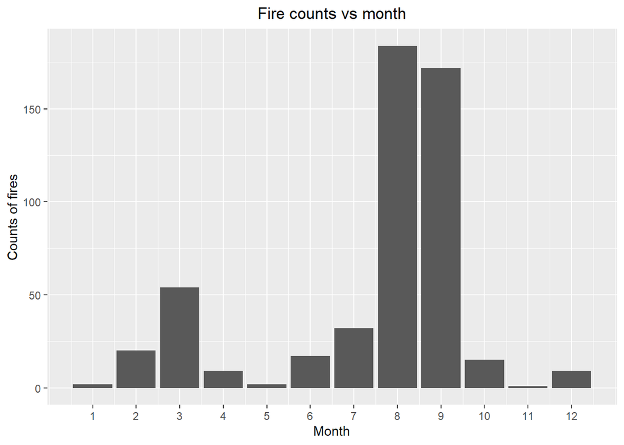

```r
# Bar plot vs month

library(ggplot2)
fires_m %>% ggplot(aes(x=month)) + geom_bar() + labs(title='Fire counts vs month', x='Month', y='Counts of fires') + theme(plot.title = element_text(hjust = 0.5)) + scale_x_continuous(breaks=seq(1,12,1))
```

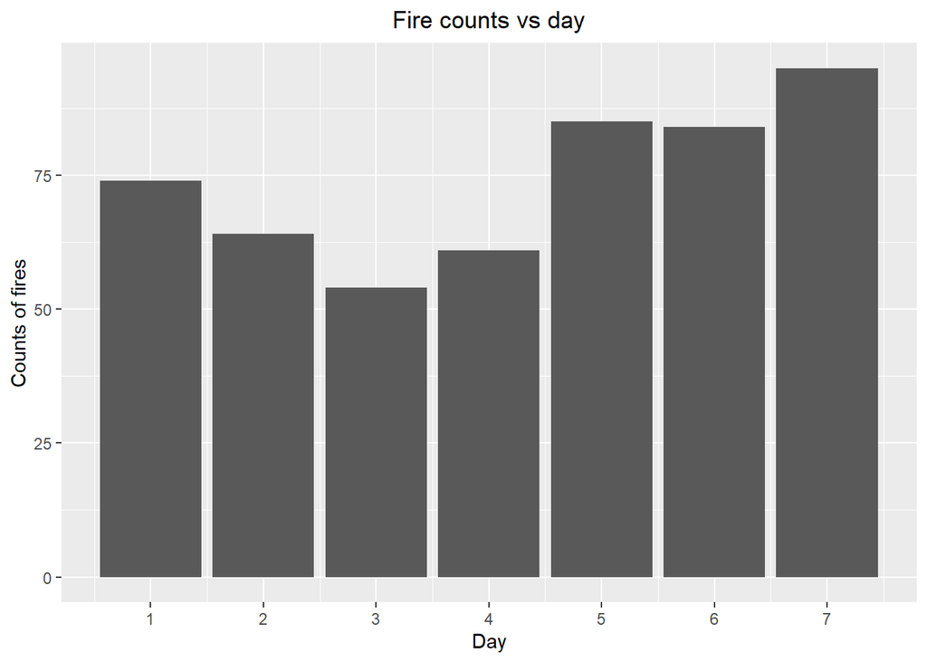

```r
# Bar plot vs day
library(ggplot2)
fires_m %>% ggplot(aes(x=day)) + geom_bar() + labs(title='Fire counts vs day', x='Day', y='Counts of fires') + theme(plot.title = element_text(hjust = 0.5)) + scale_x_continuous(breaks=seq(1,7,1))
```

### 3.2 Visulization of trends of the variables

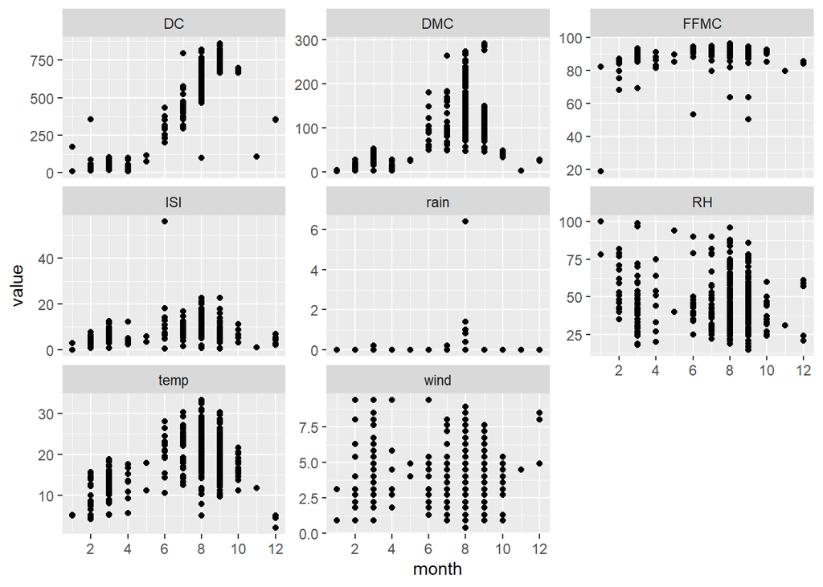

```r
library(tidyr)
# Pivot_longer function to get a column with all the variables and a column with all the values
fires_long <- fires_m %>% pivot_longer(cols=c('FFMC', 'DMC', 'DC', 'ISI', 'temp', 'RH', 'wind', 'rain'), names_to = 'column', values_to='value')

# Use facet_wrap to plot the figures
fires_long %>% ggplot(aes(x=month, y=value)) + geom_point() + facet_wrap(vars(column), scales="free_y") + xlim(0,14) + scale_x_continuous(breaks=seq(2, 12,2))
```

DC, DMC, FFMC and ISI are index based on the rain, temperature, wind and humidity. The wind and RH (relative humidity) data is scattered. There is an outlier in the rain dta. Temperature tends to be high in summer. Our goal is to predict the burned area based on these variables.

### 3.3 Visulization of target variable (burned area) and other factors

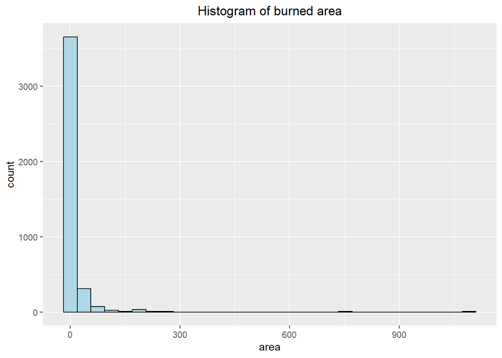

```r
# Histogram of burned area
fires_long %>% ggplot(aes(x=area)) + geom_histogram(bins=30, color='black', fill='lightblue') + labs(title='Histogram of burned area') + theme(plot.title=element_text(hjust = 0.5))
```

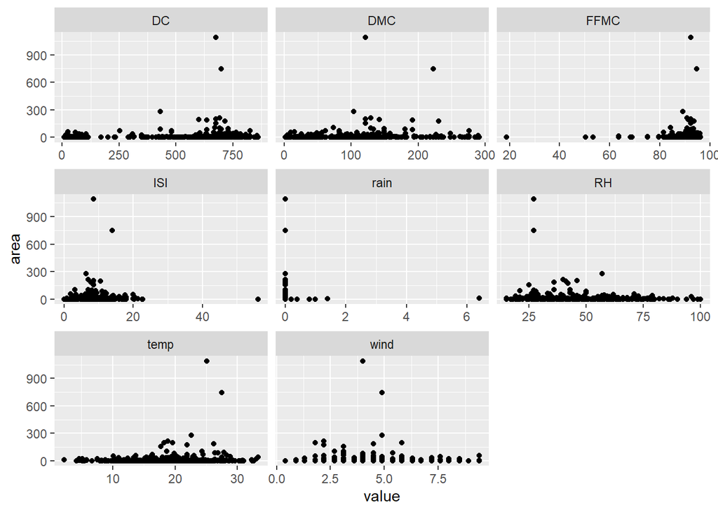

```r
# Burned area vs RH, rain...

library(ggplot2)
fires_long <- fires_m %>% pivot_longer(cols=c('FFMC', 'DMC', 'DC', 'ISI', 'temp', 'RH', 'wind', 'rain'), names_to = 'column', values_to='value')

fires_long %>% ggplot(aes(x=value, y=area)) + geom_point() + facet_wrap(vars(column), scales="free_x")
```

The histogram of the burned area shows right skewed. Most of the burned area is 0 and few burned area are large, which can seen in the scatter plot. From the scatter plot, most of the value are below 300. The outliers can be checked

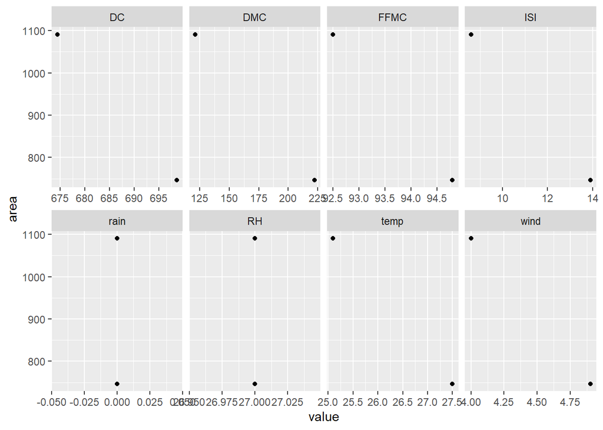

```r
# Checking the outlier
library(ggplot2)
fires_long %>% filter(area>300) %>% ggplot(aes(x=value, y=area)) + geom_point() + facet_wrap(vars(column),scales="free_x", ncol=4)
```

It can be seen only tow data points of area are above 300.

## 4. Machine Learning models

### 4.1 Prepare data for training

Data will be grouped into STFWI, STM, FWI, and M to fit the model. RAE and RMSE is for the scoring.

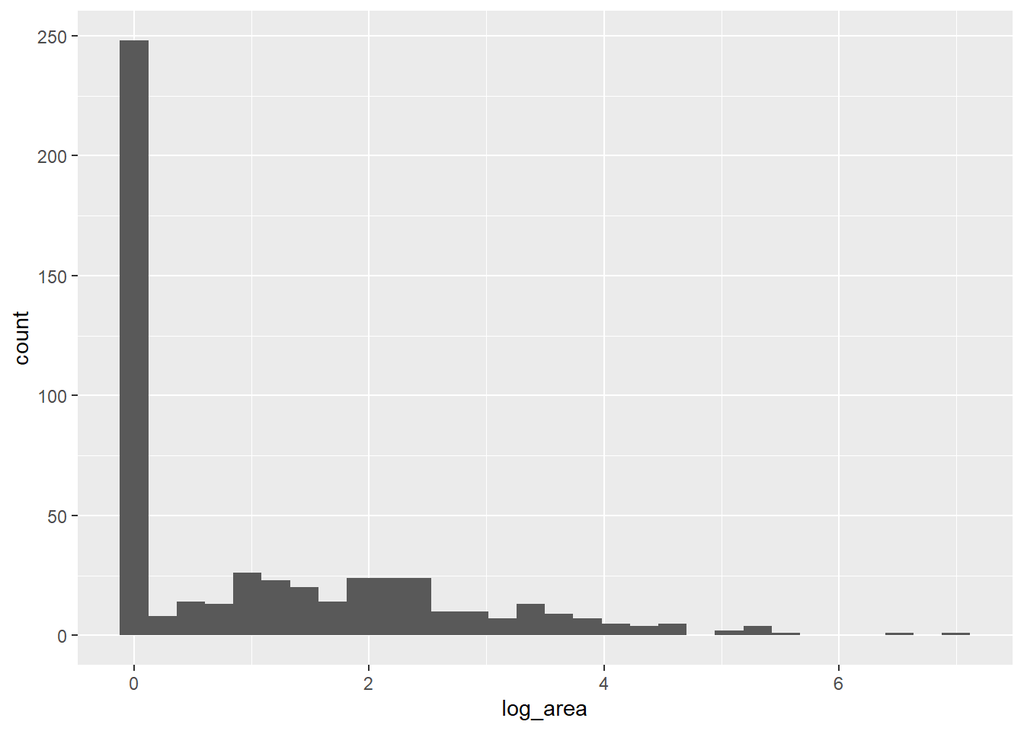

```r
# Transform area column data to reduce the skewness

fires_c <- fires_m %>% mutate(log_area= log(area+1))

ggplot(data=fires_c, aes(x=log_area)) + geom_histogram(bins=30)
```

```r
library(caret)

# Group the data

library(tibble)
STFWI <- fires_c %>%
  select(X, Y, month, day, FFMC, DMC, DC, ISI, log_area) %>% scale %>% as_tibble()

STM <- fires_c %>%
  select(X, Y, month, day, temp, RH, wind, rain, log_area)%>% scale%>% as_tibble()

FWI <- fires_c %>%
  select(FFMC, DMC, DC, ISI, log_area) %>% scale%>% as_tibble()

M <- fires_c %>%
  select(temp, RH, wind, rain, log_area) %>% scale%>% as_tibble()

# Train and test data for each group

set.seed(1)

train_indices <- createDataPartition(fires_m$area, p=0.8, list=FALSE)


  STFWI_train <- STFWI[train_indices, ]
  STFWI_test <- STFWI[-train_indices, ]

  STM_train <- STM[train_indices, ]
  STM_test <- STM[-train_indices, ]

  FWI_train <- FWI[train_indices, ]
  FWI_test <- FWI[-train_indices, ]

  M_train <- M[train_indices, ]
  M_test <- M[-train_indices, ]
```

### Model 1: Linear Regression

```r
# STFWI
fit_stfwi <- lm(log_area ~ X+Y+month+day+FFMC+DMC+DC+ISI, data=STFWI_train)
predict_stfwi <- predict(fit_stfwi, newdata = STFWI_test)
score_stfwi <- postResample(pred = predict_stfwi, obs = STFWI_test$log_area)
score_stfwi
```

```
##       RMSE   Rsquared        MAE
## 0.90668641 0.06620725 0.76563219
```

```r
# STM
fit_stm <- lm(log_area ~ X+Y+month+day+temp+RH+wind+rain, data=STM_train)
predict_stm <- predict(fit_stm, newdata = STM_test)
score_stm <- postResample(pred = predict_stm, obs = STM_test$log_area)
score_stm
```

```
##      RMSE  Rsquared       MAE
## 0.9142415 0.0433252 0.7795899
```

```r
# FWI
fit_fwi <- lm(log_area ~ FFMC+DMC+DC+ISI, data=FWI_train)
predict_fwi <- predict(fit_fwi, newdata = FWI_test)
score_fwi <- postResample(pred = predict_fwi, obs = STFWI_test$log_area)
score_fwi
```

```
##         RMSE     Rsquared          MAE
## 0.9346915035 0.0002626374 0.7914447910
```

```r
# M
fit_m <- lm(log_area ~ temp+RH+wind+rain, data=M_train)
predict_m <- predict(fit_m, newdata = M_test)
score_m <- postResample(pred = predict_m, obs = M_test$log_area)
score_m
```

```
##        RMSE    Rsquared         MAE
## 0.928488431 0.006752766 0.791486642
```

```r
# Summarize
lm_sum <- bind_rows(score_stfwi, score_stm, score_fwi, score_m)

data_group <- c('STFWI', 'STM', 'FWI', 'M')
lm_fit <-bind_cols(data_group, lm_sum) %>% as.tibble()
colnames(lm_fit)[1] = 'LM'
lm_fit
```

```
## # A tibble: 4 × 4
##   LM     RMSE Rsquared   MAE
##   <chr> <dbl>    <dbl> <dbl>
## 1 STFWI 0.907 0.0662   0.766
## 2 STM   0.914 0.0433   0.780
## 3 FWI   0.935 0.000263 0.791
## 4 M     0.928 0.00675  0.791
```

### Model 2: KNN

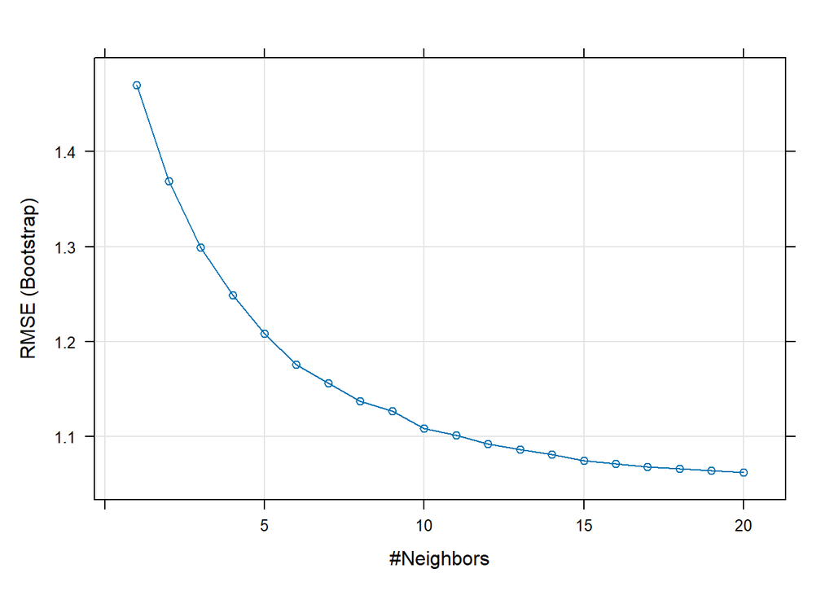

```r
# Create a model with cross validation
library(caret)

train_control <- trainControl(method='cv', number=5)
tune_grid <- expand.grid(k=1:20)

#STFWI

knn_stfwi <- train(log_area ~ X+Y+month+day+FFMC+DMC+DC+ISI,
                    data = STFWI_train,
                   method='knn',
                   preprocess=c('center', 'scale'),
                   trainControl=train_control,
                   tuneGrid=tune_grid)
plot(knn_stfwi)
```

```r
predict_stfwi <- predict(knn_stfwi, STFWI_test)
res_stfwi <- postResample(predict_stfwi, STFWI_test$log_area)
res_stfwi
```

```
##         RMSE     Rsquared          MAE
## 0.9527710717 0.0004067624 0.7940235248
```

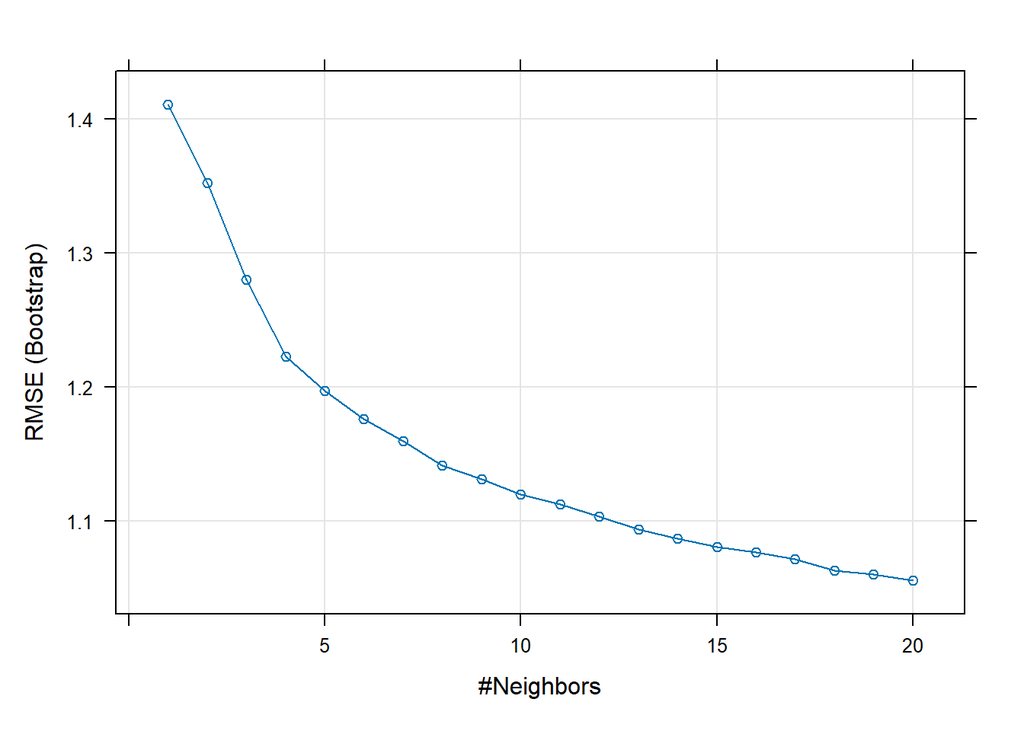

```r
#STM

knn_stm <- train(log_area ~ X+Y+month+day+temp+RH+wind+rain,
                    data = STM_train,
                   method='knn',
                   preprocess=c('center', 'scale'),
                   trainControl=train_control,
                   tuneGrid=tune_grid)
plot(knn_stm)
```

```r
predict_stm <- predict(knn_stm, STM_test)
res_stm<- postResample(predict_stm, STM_test$log_area)
res_stm
```

```
##        RMSE    Rsquared         MAE
## 0.970055972 0.004232423 0.822275703
```

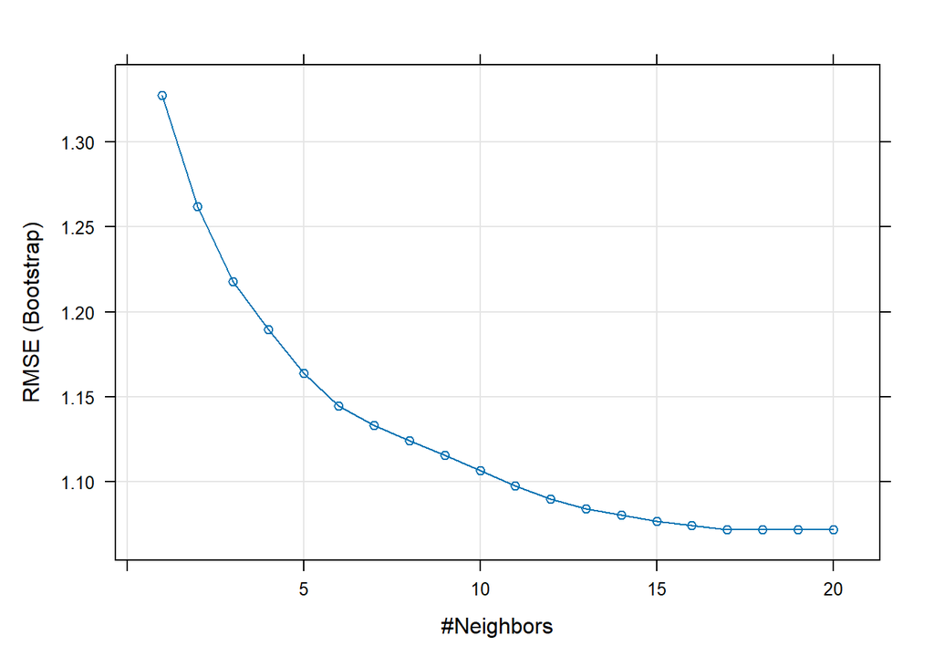

```r
#FWI

knn_fwi <- train(log_area ~ FFMC+DMC+DC+ISI,
                    data = FWI_train,
                   method='knn',
                   preprocess=c('center', 'scale'),
                   trainControl=train_control,
                   tuneGrid=tune_grid)
plot(knn_fwi)
```

```r
predict_fwi <- predict(knn_fwi, FWI_test)
res_fwi<- postResample(predict_fwi, FWI_test$log_area)
res_fwi
```

```
##         RMSE     Rsquared          MAE
## 0.9546676605 0.0000145012 0.8027886694
```

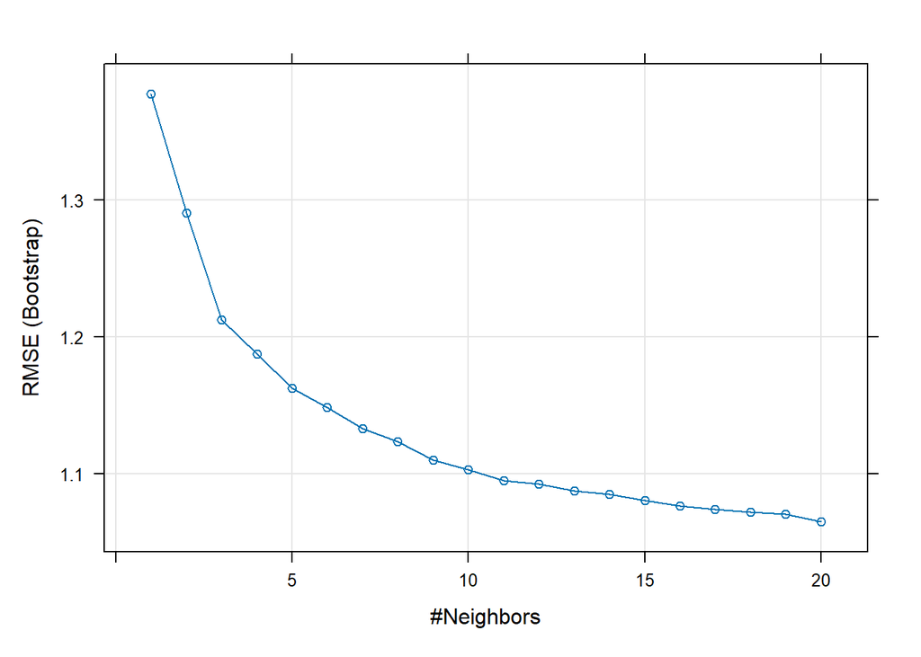

```r
#M

knn_m <- train(log_area ~ temp+RH+wind+rain,
                    data = M_train,
                   method='knn',
                   preprocess=c('center', 'scale'),
                   trainControl=train_control,
                   tuneGrid=tune_grid)
plot(knn_m)
```

```r
predict_fwi <- predict(knn_m, M_test)
res_m<- postResample(predict_m, M_test$log_area)
res_m
```

```
##        RMSE    Rsquared         MAE
## 0.928488431 0.006752766 0.791486642
```

```r
# Summarize KNN

knn_sum <- bind_rows(res_stfwi, res_stm, res_fwi, res_m)

data_group <- c('STFWI', 'STM', 'FWI', 'M')
knn_fit <-bind_cols(data_group, lm_sum) %>% as.tibble()
colnames(knn_fit)[1] = 'KNN'
knn_fit
```

```
## # A tibble: 4 × 4
##   KNN    RMSE Rsquared   MAE
##   <chr> <dbl>    <dbl> <dbl>
## 1 STFWI 0.907 0.0662   0.766
## 2 STM   0.914 0.0433   0.780
## 3 FWI   0.935 0.000263 0.791
## 4 M     0.928 0.00675  0.791
```

```r
# Summarize lm and knn
cols <-  c('STFWI_lm', 'STFWI_knn','STM_lm', 'STM_knn','FWI_lm', 'FWI_knn', 'M_lm', 'M_knn')
combine <- bind_rows(score_stfwi, score_stfwi, score_stm, res_stm, score_fwi, res_fwi, score_m,  res_m)

combine_scores <- bind_cols(cols, combine)
combine_scores
```

```
## # A tibble: 8 × 4
##   ...1       RMSE  Rsquared   MAE
##   <chr>     <dbl>     <dbl> <dbl>
## 1 STFWI_lm  0.907 0.0662    0.766
## 2 STFWI_knn 0.907 0.0662    0.766
## 3 STM_lm    0.914 0.0433    0.780
## 4 STM_knn   0.970 0.00423   0.822
## 5 FWI_lm    0.935 0.000263  0.791
## 6 FWI_knn   0.955 0.0000145 0.803
## 7 M_lm      0.928 0.00675   0.791
## 8 M_knn     0.928 0.00675   0.791
```